# Text Analysis of Trump’s Tweets in 2016 with `tidytext`

**Note**: The code for this text analysis was modified from David Robinson’s GitHub account at https://github.com/dgrtwo/dgrtwo.github.com/blob/master/_R/2016-08-09-trump-tweets.Rmd.

We will use this link a couple of times to understand regexes: https://medium.com/factory-mind/regex-tutorial-a-simple-cheatsheet-by-examples-649dc1c3f285

In this text analysis, we will follow along with the modified code here to perform a basic sentiment analysis on Trump’s tweets, comparing his tweets from an Android device and an iPhone. There was a major news story that broke out in 2016 that speculated that the iPhone was a campaign device (used by staffers to tweet from Trump’s twitter account) while the Android device was used by Trump himself. We will investigate why with the following text analysis.

### The dataset

While you can upload twitter data from anyone’s public account with the `twitteR` package, you need to create an account first. We will skip this step by directly reading in the data set from the author’s website `varianceexplained`:

```r
load(url("http://varianceexplained.org/files/trump_tweets_df.rda"))
```

We clean this data a bit, extracting the source application. (We’re looking only at the iPhone and Android tweets- a much smaller number are from the web client or iPad).

```r
library(ggplot2)
theme_set(theme_bw())
library(dplyr)
library(tidyr)
tweets <- trump_tweets_df |>
  select(id, statusSource, text, created) |>
  extract(statusSource, "source", "Twitter for (.*?)<") |>
  filter(source %in% c("iPhone", "Android"))
```

Overall, this includes 628 tweets from iPhone, and 762 tweets from Android.

One consideration is what time of day the tweets occur, which we’d expect to be a “signature” of their user. Here we can certainly spot a difference:

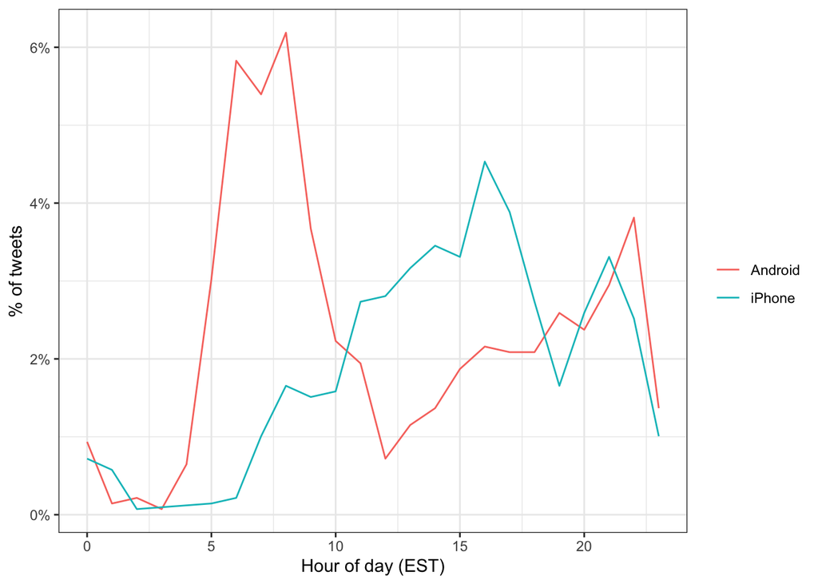

```r
library(lubridate)
library(scales)
tweets |>
  mutate(hour = hour(with_tz(created, "EST"))) |>
  group_by(source, hour) |>
  summarise(n = n()) |>
  ungroup() |>
  mutate(percent = n / sum(n)) |>
  ggplot(aes(hour, percent, color = source)) +
  geom_line() +
  scale_y_continuous(labels = percent_format()) +
  labs(x = "Hour of day (EST)",
       y = "% of tweets",
       color = "")
```

Another place we can spot a difference is in Trump’s anachronistic behavior of “manually retweeting” people by copy-pasting their tweets, then surrounding them with quotation marks:

Almost all of these quoted tweets are posted from the Android:

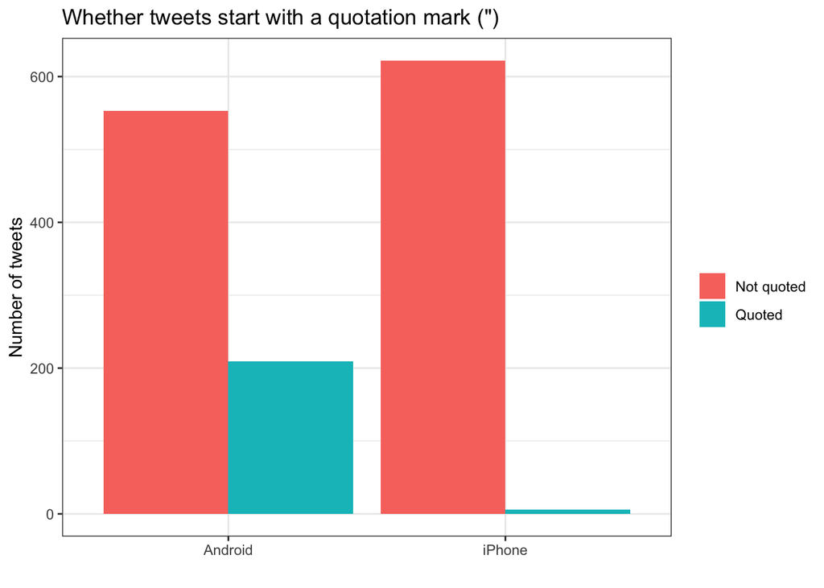

In the remaining by-word analyses in this text, I’ll filter these quoted tweets out (since they contain text from followers that may not be representative of Trump’s own tweets).

### Comparison of words

Now that we’re sure there’s a difference between these two accounts, what can we say about the difference in the *content*? We’ll use the tidytext package that [Julia Silge](http://juliasilge.com/) and the author of this post developed.

In the following code chunk, we will comment what each line of code is doing.

```r
## install.packages("tidytext")
library(tidytext)

tweet_words <- tweets |>
  filter(!str_detect(text, '^"')) |>
  mutate(text = str_replace_all(text, "https://t.co/[A-Za-z\\d]+|&amp;", "")) |>
  unnest_tokens(word, text) |>
  anti_join(stop_words, by = c("word" = "word")) |>
  filter(str_detect(word, "[a-z]"))

tweet_words
```

```
# A tibble: 8,825 × 4
   id                 source  created             word
   <chr>              <chr>   <dttm>              <chr>
 1 762669882571980801 Android 2016-08-08 15:20:44 economic
 2 762669882571980801 Android 2016-08-08 15:20:44 policy
 3 762669882571980801 Android 2016-08-08 15:20:44 speech
 4 762669882571980801 Android 2016-08-08 15:20:44 carried
 5 762669882571980801 Android 2016-08-08 15:20:44 live
 6 762669882571980801 Android 2016-08-08 15:20:44 p.m
 7 762669882571980801 Android 2016-08-08 15:20:44 enjoy
 8 762641595439190016 iPhone  2016-08-08 13:28:20 join
 9 762641595439190016 iPhone  2016-08-08 13:28:20 fayetteville
10 762641595439190016 iPhone  2016-08-08 13:28:20 north
# … with 8,815 more rows
```

What were the most common words in Trump’s tweets overall?

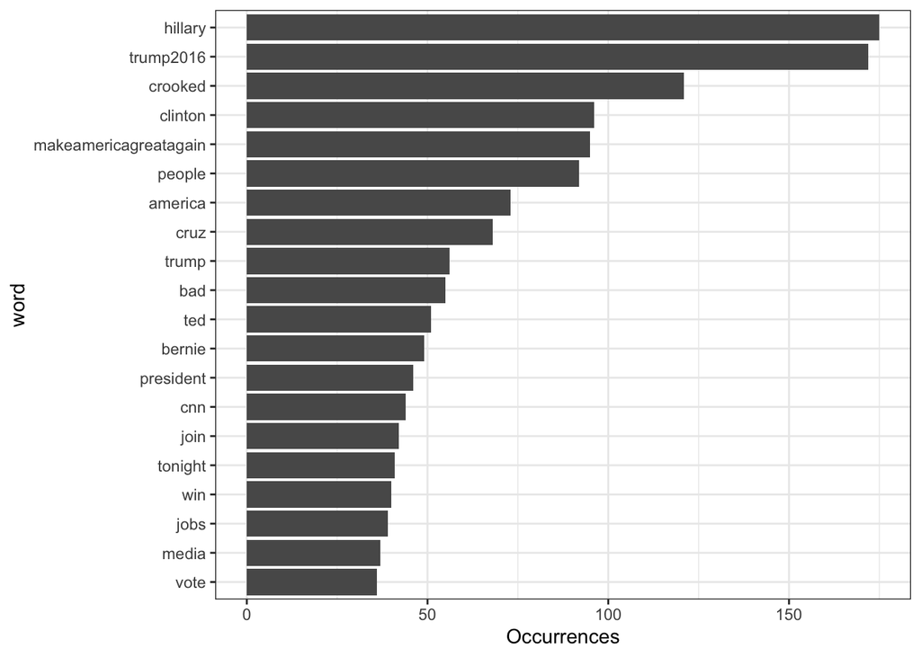

```r
library(forcats)
tweet_words |>
  group_by(word) |>
  summarise(n = n()) |>
  arrange(desc(n)) |>
  head(20) |>
  mutate(word = fct_reorder(word, n)) |>
  ggplot(aes(word, n)) +
  geom_bar(stat = "identity") +
  ylab("Occurrences") +
  coord_flip()
```

$$\log_2(\frac{\frac{\mbox{# in Android} + 1}{\mbox{Total Android} + 1}}
{\frac{\mbox{# in iPhone} + 1}{\mbox{Total iPhone} + 1}})$$

We won’t focus on the details of this log odds ratio calculation: the most important thing to note is that, the higher the log ratio is for a word, the more often that word appeared on the andriod device compared to the iphone device. The more negative the log odds ratio, the more often that word appeared on the iphone device compared to the android device.

```r
android_iphone_ratios <- tweet_words |>
  group_by(word, source) |>
  summarise(n = n()) |>
  filter(sum(n) >= 5) |>
  pivot_wider(names_from = "source", values_from = "n",
              values_fill = 0) |>
  ungroup() |>
  mutate(across(where(is.numeric), ~ (. + 1) / sum(. + 1))) |>
  mutate(logratio = log2(Android / iPhone)) |>
  arrange(desc(logratio))
```

Which are the words most likely to be from Android and most likely from iPhone?

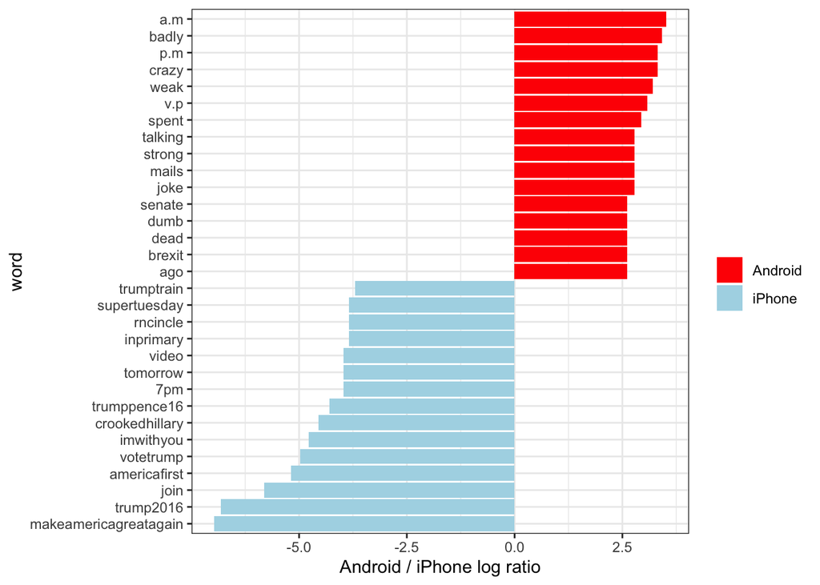

```r
android_iphone_ratios |>
  group_by(logratio > 0) |>
  top_n(15, abs(logratio)) |>
  ungroup() |>
  mutate(word = reorder(word, logratio)) |>
  ggplot(aes(word, logratio, fill = logratio < 0)) +
  geom_bar(stat = "identity") +
  coord_flip() +
  ylab("Android / iPhone log ratio") +
  scale_fill_manual(name = "", labels = c("Android", "iPhone"),
                    values = c("red", "lightblue"))
```

What are some patterns you can discern from the types of words that more frequently on the Android account compared to the iPhone account?

### Sentiment analysis

Since we’ve observed a difference in sentiment between the Android and iPhone tweets, let’s try quantifying it. We’ll work with the [NRC Word-Emotion Association](http://saifmohammad.com/WebPages/NRC-Emotion-Lexicon.htm) lexicon, available from the tidytext package, which associates words with 10 sentiments: **positive**, **negative**, **anger**, **anticipation**, **disgust**, **fear**, **joy**, **sadness**, **surprise**, and **trust**.

```r
## install.packages("textdata")
library(textdata)
sentiment_df <- get_sentiments("nrc")
nrc <- sentiment_df |>
  dplyr::select(word, sentiment)
nrc
```

```
# A tibble: 13,875 × 2
   word        sentiment
   <chr>       <chr>
 1 abacus      trust
 2 abandon     fear
 3 abandon     negative
 4 abandon     sadness
 5 abandoned   anger
 6 abandoned   fear
 7 abandoned   negative
 8 abandoned   sadness
 9 abandonment anger
10 abandonment fear
# … with 13,865 more rows
```

To measure the sentiment of the Android and iPhone tweets, we can count the number of words in each category:

```r
sources <- tweet_words |>
  group_by(source) |>
  mutate(total_words = n()) |>
  ungroup() |>
  distinct(id, source, total_words)

by_source_sentiment <- tweet_words |>
  inner_join(nrc, by = "word") |>
  count(sentiment, id) |>
  ungroup() |>
  complete(sentiment, id, fill = list(n = 0)) |>
  inner_join(sources) |>
  group_by(source, sentiment, total_words) |>
  summarize(words = sum(n)) |>
  ungroup()
by_source_sentiment
```

```
# A tibble: 20 × 4
   source  sentiment    total_words words
   <chr>   <chr>              <int> <int>
 1 Android anger               4975   321
 2 Android anticipation        4975   256
 3 Android disgust             4975   207
 4 Android fear                4975   268
 5 Android joy                 4975   198
 6 Android negative            4975   556
 7 Android positive            4975   553
 8 Android sadness             4975   302
 9 Android surprise            4975   160
10 Android trust               4975   368
11 iPhone  anger               3850   169
12 iPhone  anticipation        3850   172
13 iPhone  disgust             3850    95
14 iPhone  fear                3850   135
15 iPhone  joy                 3850   156
16 iPhone  negative            3850   258
17 iPhone  positive            3850   410
18 iPhone  sadness             3850   147
19 iPhone  surprise            3850   108
20 iPhone  trust               3850   255
```

Describe what the code above is creating.

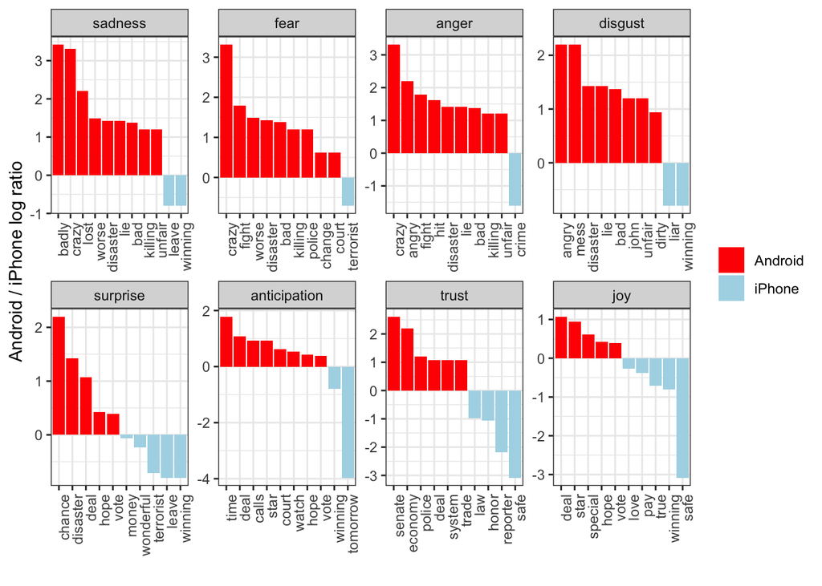

```r
android_iphone_ratios |>
    inner_join(nrc, by = "word") |>
  filter(!sentiment %in% c("positive", "negative")) |>
  mutate(sentiment = reorder(sentiment, -logratio),
         word = reorder(word, -logratio)) |>
  group_by(sentiment) |>
  top_n(10, abs(logratio)) |>
  ungroup() |>
  ggplot(aes(word, logratio, fill = logratio < 0)) +
  facet_wrap(~ sentiment, scales = "free", nrow = 2) +
  geom_bar(stat = "identity") +
  theme(axis.text.x = element_text(angle = 90, hjust = 1)) +
  labs(x = "", y = "Android / iPhone log ratio") +
  scale_fill_manual(name = "", labels = c("Android", "iPhone"),
                    values = c("red", "lightblue"))
```

What are some patterns that you see in the sentiments for the tweets from the Android phone compared to the iPhone. Again, a higher log ratio means that the word was used more often on the android phone while a negative log ratio means that the word was used more often on the iPhone.

The author’s original write-up for this analysis is here: https://blog.revolutionanalytics.com/2016/08/sentiment-analysis-of-trumps-tweets-with-r.html.